# Analysis of the effects of the 2017 Travel Ban Executive order

### By Austin Chi, Vuong Nguyen, and Spencer Phillips

We were curious what some of the effects of the 2017 Travel Ban executive order signed by President Donald Trump on individuals and wanted to answer a few specific questions.

```
1. Looking at the 7 countries targeted by the ban, how many people would be refused greencards over a 90 day period? What proportion would be refugees?
-howandwheregreencard.xls
Assume refugee applicants for 2017 are roughly the same as 2015 and the applicants are distributed iid Uniformly over the year.

2. With Refugees, where do they come from? What country brings the highest proportion of refugees vs Green Card holders? Do these countries have more refugees than others on average?
-HowAndWhereGreenCard.xls
Plot on map showing number of immigrants and proportion of immigrants that are refugees.

3. How many of these individuals would be deported? How many for doing illegal things?
-RemovedByCrimAndNationality.xls

4.Analysis public sentiment for the ban.
Twitter API for public sentiment.
```

We asked these to see more into what this ban would do to the United States as a whole using data from 2015 from the US Department of Homeland Security. This data will be analyzed through pandas and visualized in different ways.

## Packages Used

First the packages we are going to be using will include pandas and numpy for organizing our data, matplotlib in order to graph things and using the gg plot style. The ttest_ind will be used for our t test later on in the analysis which is important to look at. The "Austin" package was created by Austin in order to save our tables to an sqllite file and is also used in the scraping of Twitter later on to form our overarching dataset for our analysis later on. Basemap, Polygon, Normalize, and PatchCollection is used in the formation of our maps later on for visualization.

```python
import pandas as pd
import numpy as np
import Austin
import matplotlib.pyplot as plt
from scipy.stats import ttest_ind
import matplotlib
matplotlib.style.use('ggplot')
import matplotlib.cm
from mpl_toolkits.basemap import Basemap
from matplotlib.patches import Polygon
from matplotlib.collections import PatchCollection
from matplotlib.colors import Normalize
import scipy
```

## Working with the DHS data

First we need to take the DHS data and put it into a dataframe. In the excel doc, values with a D are nondisclosed values for secrecy, so we made those into NAs and also made it so there are Trues and Falses for if the country is considered banned or not in the collumn 'banned'. There is also a column called 'refugee_to_total' which will have the proportion of green card holders that are refugees. All relevant collumns are turned into np.float values in order to be used on each other. Country of birth is changed to country for the mapping later on.

```python
greencard = pd.read_excel('HowAndWhereGreenCard.xls',sheetname='Country',
              skiprows=[0,1,2], skip_footer=4,na_values = ['D'])
greencard['refugee_to_total']=''
greencard['banned']=''
greencard['Total'] = greencard['Total'].astype(np.float64)
bannedcount = ['Iran','Iraq','Libya','Somalia', 'Sudan','Syria','Yemen']
for x in xrange(len(greencard)):
    if greencard['Country of birth'][x] in bannedcount:
        greencard['banned'][x] = True
    else:
        greencard['banned'][x] = False
for x in xrange(len(greencard)):
    greencard['refugee_to_total'][x]=greencard['Refugees and asylees'][x]/greencard['Total'][x]
greencard['refugee_to_total']=greencard['refugee_to_total'].astype(np.float)
greencard.rename(columns={'Country of birth':'country'}, inplace=True)
```

```python
greencard = greencard[1:]
greencard
```

|  | country | Total | Family-sponsored preferences | Employment-based preferences | Immediate relatives of U.S. citizens | Diversity | Refugees and asylees | Other | refugee_to_total | banned |
| --- | --- | --- | --- | --- | --- | --- | --- | --- | --- | --- |
| 1 | Afghanistan | 8328.0 | 272.0 | 16.0 | 1011.0 | 50.0 | 691.0 | 6288.0 | 0.082973 | False |
| 2 | Albania | 4653.0 | 614.0 | 81.0 | 2017.0 | 1770.0 | 152.0 | 19.0 | 0.032667 | False |
| 3 | Algeria | 1775.0 | 103.0 | 40.0 | 570.0 | 1035.0 | 19.0 | 8.0 | 0.010704 | False |
| 4 | Angola | 154.0 | 8.0 | 12.0 | 89.0 | 6.0 | 39.0 | 0.0 | 0.253247 | False |
| 5 | Anguilla | 22.0 | NaN | NaN | 18.0 | 0.0 | 0.0 | 1.0 | 0.000000 | False |
| 6 | Antigua-Barbuda | 290.0 | 97.0 | 12.0 | 176.0 | NaN | 0.0 | NaN | 0.000000 | False |
| 7 | Argentina | 3730.0 | 194.0 | 1095.0 | 2194.0 | 48.0 | 133.0 | 66.0 | 0.035657 | False |
| 8 | Armenia | 2962.0 | 247.0 | 120.0 | 1035.0 | 1324.0 | 225.0 | 11.0 | 0.075962 | False |
| 9 | Aruba | 38.0 | 4.0 | 4.0 | 30.0 | 0.0 | 0.0 | 0.0 | 0.000000 | False |
| 10 | Australia | 3034.0 | 68.0 | 930.0 | 1636.0 | 390.0 | NaN | NaN | NaN | False |
| 11 | Austria | 474.0 | 17.0 | 166.0 | 247.0 | 39.0 | 5.0 | 0.0 | 0.010549 | False |
| 12 | Azerbaijan | 676.0 | 70.0 | 34.0 | 291.0 | 229.0 | 49.0 | 3.0 | 0.072485 | False |
| 13 | Bahamas | 725.0 | 53.0 | 84.0 | 562.0 | 6.0 | 14.0 | 6.0 | 0.019310 | False |
| 14 | Bahrain | 145.0 | 24.0 | 60.0 | 47.0 | NaN | NaN | 0.0 | NaN | False |
| 15 | Bangladesh | 13570.0 | 7044.0 | 653.0 | 5667.0 | 0.0 | 167.0 | 39.0 | 0.012307 | False |
| 16 | Barbados | 376.0 | 97.0 | 28.0 | 235.0 | 9.0 | 0.0 | 7.0 | 0.000000 | False |
| 17 | Belarus | 1994.0 | 86.0 | 236.0 | 695.0 | 772.0 | 199.0 | 6.0 | 0.099799 | False |
| 18 | Belgium | 662.0 | 14.0 | 303.0 | 298.0 | 40.0 | NaN | NaN | NaN | False |
| 19 | Belize | 772.0 | 182.0 | 35.0 | 537.0 | 0.0 | 5.0 | 13.0 | 0.006477 | False |
| 20 | Benin | 466.0 | 19.0 | 11.0 | 233.0 | 180.0 | 19.0 | 4.0 | 0.040773 | False |
| 21 | Bermuda | 112.0 | 19.0 | 13.0 | 77.0 | 0.0 | NaN | NaN | NaN | False |
| 22 | Bhutan | 6325.0 | NaN | 4.0 | 28.0 | NaN | 6290.0 | 0.0 | 0.994466 | False |
| 23 | Bolivia | 1626.0 | 248.0 | 220.0 | 1038.0 | 17.0 | 43.0 | 60.0 | 0.026445 | False |
| 24 | Bosnia-Herzegovina | 859.0 | NaN | 66.0 | 602.0 | 69.0 | 64.0 | NaN | 0.074505 | False |
| 25 | Botswana | 61.0 | 3.0 | 6.0 | 28.0 | 6.0 | 18.0 | 0.0 | 0.295082 | False |
| 26 | Brazil | 11424.0 | 452.0 | 2725.0 | 7903.0 | 21.0 | 116.0 | 207.0 | 0.010154 | False |
| 27 | British Virgin Islands | 38.0 | 10.0 | NaN | 24.0 | 0.0 | 0.0 | NaN | 0.000000 | False |
| 28 | Brunei | 21.0 | 3.0 | 8.0 | 10.0 | 0.0 | 0.0 | 0.0 | 0.000000 | False |
| 29 | Bulgaria | 2688.0 | 130.0 | 301.0 | 1379.0 | 819.0 | 45.0 | 14.0 | 0.016741 | False |
| 30 | Burkina Faso | 575.0 | 33.0 | 15.0 | 274.0 | 98.0 | 152.0 | 3.0 | 0.264348 | False |
| ... | ... | ... | ... | ... | ... | ... | ... | ... | ... | ... |
| 171 | Suriname | 134.0 | 32.0 | 8.0 | 91.0 | NaN | 0.0 | NaN | 0.000000 | False |
| 172 | Swaziland | 19.0 | 0.0 | 5.0 | 14.0 | 0.0 | 0.0 | 0.0 | 0.000000 | False |
| 173 | Sweden | 1066.0 | 27.0 | 393.0 | 581.0 | 50.0 | 12.0 | 3.0 | 0.011257 | False |
| 174 | Switzerland | 640.0 | 10.0 | 251.0 | 331.0 | 34.0 | 8.0 | 6.0 | 0.012500 | False |
| 175 | Syria | 3840.0 | 801.0 | 250.0 | 1507.0 | 140.0 | 1137.0 | 5.0 | 0.296094 | True |
| 176 | Taiwan | 4888.0 | 662.0 | 2119.0 | 1950.0 | 138.0 | NaN | NaN | NaN | False |
| 177 | Tajikistan | 595.0 | 25.0 | 44.0 | 188.0 | 277.0 | 61.0 | 0.0 | 0.102521 | False |
| 178 | Tanzania | 799.0 | 59.0 | NaN | 406.0 | 66.0 | 211.0 | NaN | 0.264080 | False |
| 179 | Thailand | 7502.0 | 291.0 | 336.0 | 3288.0 | 25.0 | 3439.0 | 123.0 | 0.458411 | False |
| 180 | Togo | 1547.0 | 155.0 | 16.0 | 669.0 | 537.0 | 157.0 | 13.0 | 0.101487 | False |
| 181 | Tonga | 327.0 | 103.0 | NaN | 210.0 | NaN | 0.0 | 0.0 | 0.000000 | False |
| 182 | Trinidad and Tobago | 3212.0 | 651.0 | 272.0 | 2188.0 | 53.0 | 4.0 | 44.0 | 0.001245 | False |
| 183 | Tunisia | 518.0 | 20.0 | 56.0 | 351.0 | 41.0 | 45.0 | 5.0 | 0.086873 | False |
| 184 | Turkey | 4201.0 | 222.0 | 1041.0 | 1670.0 | 1108.0 | 142.0 | 18.0 | 0.033801 | False |
| 185 | Turkmenistan | 226.0 | NaN | 20.0 | 68.0 | 90.0 | 35.0 | NaN | 0.154867 | False |
| 186 | Turks and Caicos Islands | 38.0 | 3.0 | NaN | 30.0 | 0.0 | NaN | 2.0 | NaN | False |
| 187 | Uganda | 1664.0 | 122.0 | 135.0 | 686.0 | 185.0 | 531.0 | 5.0 | 0.319111 | False |
| 188 | Ukraine | 7987.0 | 797.0 | 881.0 | 4519.0 | 1285.0 | 471.0 | 34.0 | 0.058971 | False |
| 189 | United Arab Emirates | 1193.0 | 209.0 | 312.0 | 303.0 | 118.0 | 238.0 | 13.0 | 0.199497 | False |
| 190 | United Kingdom | 12592.0 | 492.0 | 5459.0 | 6481.0 | 92.0 | 31.0 | 37.0 | 0.002462 | False |
| 191 | United States | 370.0 | 12.0 | 43.0 | 270.0 | 0.0 | 19.0 | 26.0 | 0.051351 | False |
| 192 | Uruguay | 1078.0 | 37.0 | 115.0 | 834.0 | 5.0 | 47.0 | 40.0 | 0.043599 | False |
| 193 | Uzbekistan | 3977.0 | 396.0 | 131.0 | 805.0 | 2318.0 | 306.0 | 21.0 | 0.076942 | False |
| 194 | Venezuela | 9144.0 | 731.0 | 2207.0 | 4610.0 | 738.0 | 806.0 | 52.0 | 0.088145 | False |
| 195 | Vietnam | 30832.0 | 16065.0 | 872.0 | 13690.0 | NaN | 148.0 | NaN | 0.004800 | False |
| 196 | Yemen | 3194.0 | 577.0 | 25.0 | 2319.0 | 136.0 | 134.0 | 3.0 | 0.041954 | True |
| 197 | Zambia | 460.0 | 31.0 | 75.0 | 272.0 | 35.0 | 44.0 | 3.0 | 0.095652 | False |
| 198 | Zimbabwe | 779.0 | 60.0 | 167.0 | 311.0 | 42.0 | 189.0 | 10.0 | 0.242619 | False |
| 199 | All other countries1 | 73.0 | 7.0 | 15.0 | 44.0 | NaN | NaN | 0.0 | NaN | False |
| 200 | Unknown | 677.0 | 112.0 | 36.0 | 411.0 | 22.0 | 53.0 | 43.0 | 0.078287 | False |

200 rows × 10 columns

Next, we are going to work on the values for the people who were removed from the country. In this case we have to change both D's and X's into NaNs since some were not disclosed due again to privacy issues.

```python
removal = pd.read_excel('RemovedByCrimAndNationality.xls',sheetname='Country',
              skiprows=[0,1,2], skip_footer=7,na_values = ['D','X'])
```

For this dataset, they were split by year so we had do specifically pick the 2015 row by using loc(). We again changed the name of the country to 'country' to ease mapping later on.

```python
remove2015 = removal.loc[:,['Country of nationality', '2015','Unnamed: 29','Unnamed: 30']]
remove2015.rename(columns={'Country of nationality':'country'}, inplace=True)
remove2015
```

|  | country | 2015 | Unnamed: 29 | Unnamed: 30 |
| --- | --- | --- | --- | --- |
| 0 | NaN | Total | Criminal 1 | Non-Criminal |
| 1 | Total | 333341 | 139950 | 193391 |
| 2 | Afghanistan | 9 | NaN | NaN |
| 3 | Albania | 40 | 21 | 19 |
| 4 | Algeria | 14 | NaN | NaN |
| 5 | Angola | 10 | 3 | 7 |
| 6 | Antigua-Barbuda | 16 | 11 | 5 |
| 7 | Argentina | 132 | 58 | 74 |
| 8 | Armenia | 16 | NaN | NaN |
| 9 | Australia | 32 | 16 | 16 |
| 10 | Austria | 7 | 3 | 4 |
| 11 | Bahamas | 73 | 66 | 7 |
| 12 | Bangladesh | 64 | 13 | 51 |
| 13 | Barbados | 12 | 12 | 0 |
| 14 | Belarus | 8 | NaN | NaN |
| 15 | Belgium | 7 | 4 | 3 |
| 16 | Belize | 134 | 83 | 51 |
| 17 | Benin | 8 | 3 | 5 |
| 18 | Bermuda | 11 | 7 | 4 |
| 19 | Bolivia | 69 | 37 | 32 |
| 20 | Bosnia-Herzegovina | 55 | 43 | 12 |
| 21 | Brazil | 992 | 282 | 710 |
| 22 | Bulgaria | 34 | 17 | 17 |
| 23 | Burkina Faso | 24 | NaN | NaN |
| 24 | Burma | 5 | NaN | NaN |
| 25 | Cambodia | 15 | 15 | 0 |
| 26 | Cameroon | 31 | 11 | 20 |
| 27 | Canada | 629 | 258 | 371 |
| 28 | Cape Verde | 8 | 4 | 4 |
| 29 | Chad | 4 | 0 | 4 |
| ... | ... | ... | ... | ... |
| 133 | Spain | 100 | 31 | 69 |
| 134 | Sri Lanka | 19 | 3 | 16 |
| 135 | Sudan | 11 | 6 | 5 |
| 136 | Suriname | 5 | NaN | NaN |
| 137 | Sweden | 17 | 6 | 11 |
| 138 | Switzerland | 4 | NaN | NaN |
| 139 | Syria | 4 | 0 | 4 |
| 140 | Taiwan | 31 | 9 | 22 |
| 141 | Tajikistan | 3 | NaN | NaN |
| 142 | Tanzania | 19 | 10 | 9 |
| 143 | Thailand | 53 | 15 | 38 |
| 144 | Togo | 11 | 3 | 8 |
| 145 | Tonga | 19 | 12 | 7 |
| 146 | Trinidad and Tobago | 126 | 102 | 24 |
| 147 | Tunisia | 16 | 7 | 9 |
| 148 | Turkey | 52 | 14 | 38 |
| 149 | Turks and Caicos Islands | NaN | NaN | NaN |
| 150 | Uganda | 9 | 4 | 5 |
| 151 | Ukraine | 89 | 39 | 50 |
| 152 | United Arab Emirates | NaN | 0 | NaN |
| 153 | United Kingdom | 149 | 94 | 55 |
| 154 | Uruguay | 34 | 16 | 18 |
| 155 | Uzbekistan | 14 | 8 | 6 |
| 156 | Venezuela | 204 | 61 | 143 |
| 157 | Vietnam | 45 | 18 | 27 |
| 158 | Yemen | 13 | 7 | 6 |
| 159 | Zambia | 13 | NaN | NaN |
| 160 | Zimbabwe | 11 | 6 | 5 |
| 161 | All other countries 2 | 38 | 19 | 19 |
| 162 | Unknown | 35 | 15 | 20 |

163 rows × 4 columns

We had to remove the first row due to it being a descriptive row which was done below. We also added a T/F for if the country was on the banned list and got a proportion that was the proportion of criminal removals vs overall removals

```python
new_header = remove2015.iloc[0]
new_header =list(new_header)
new_header = ['country'] +list(new_header)
del new_header[1]
remove2015.columns = new_header
remove2015 = remove2015[2:]
remove2015['proportion_crim'] = ''
remove2015['banned']=''
remove2015.reset_index(inplace=True)
del remove2015['index']
for x in xrange(len(remove2015)):
    if remove2015['country'][x] in bannedcount:
        remove2015['banned'][x] = True
    else:
        remove2015['banned'][x] = False
for x in xrange(len(remove2015)):
    if float(remove2015['Total'][x])!=0:
        remove2015['proportion_crim'][x]=float(remove2015[u'Criminal 1'][x])/float(remove2015['Total'][x])
    else:
        remove2015['proportion_crim'][x]=0
```

```python
remove2015['Total']=remove2015['Total'].astype(np.float)
remove2015['Criminal 1']=remove2015['Criminal 1'].astype(np.float)
remove2015['proportion_crim']=remove2015['proportion_crim'].astype(np.float)
remove2015['Non-Criminal']=remove2015['Non-Criminal'].astype(np.float)
remove2015
```

|  | country | Total | Criminal 1 | Non-Criminal | proportion_crim | banned |
| --- | --- | --- | --- | --- | --- | --- |
| 0 | Afghanistan | 9.0 | NaN | NaN | NaN | False |
| 1 | Albania | 40.0 | 21.0 | 19.0 | 0.525000 | False |
| 2 | Algeria | 14.0 | NaN | NaN | NaN | False |
| 3 | Angola | 10.0 | 3.0 | 7.0 | 0.300000 | False |
| 4 | Antigua-Barbuda | 16.0 | 11.0 | 5.0 | 0.687500 | False |
| 5 | Argentina | 132.0 | 58.0 | 74.0 | 0.439394 | False |
| 6 | Armenia | 16.0 | NaN | NaN | NaN | False |
| 7 | Australia | 32.0 | 16.0 | 16.0 | 0.500000 | False |
| 8 | Austria | 7.0 | 3.0 | 4.0 | 0.428571 | False |
| 9 | Bahamas | 73.0 | 66.0 | 7.0 | 0.904110 | False |
| 10 | Bangladesh | 64.0 | 13.0 | 51.0 | 0.203125 | False |
| 11 | Barbados | 12.0 | 12.0 | 0.0 | 1.000000 | False |
| 12 | Belarus | 8.0 | NaN | NaN | NaN | False |
| 13 | Belgium | 7.0 | 4.0 | 3.0 | 0.571429 | False |
| 14 | Belize | 134.0 | 83.0 | 51.0 | 0.619403 | False |
| 15 | Benin | 8.0 | 3.0 | 5.0 | 0.375000 | False |
| 16 | Bermuda | 11.0 | 7.0 | 4.0 | 0.636364 | False |
| 17 | Bolivia | 69.0 | 37.0 | 32.0 | 0.536232 | False |
| 18 | Bosnia-Herzegovina | 55.0 | 43.0 | 12.0 | 0.781818 | False |
| 19 | Brazil | 992.0 | 282.0 | 710.0 | 0.284274 | False |
| 20 | Bulgaria | 34.0 | 17.0 | 17.0 | 0.500000 | False |
| 21 | Burkina Faso | 24.0 | NaN | NaN | NaN | False |
| 22 | Burma | 5.0 | NaN | NaN | NaN | False |
| 23 | Cambodia | 15.0 | 15.0 | 0.0 | 1.000000 | False |
| 24 | Cameroon | 31.0 | 11.0 | 20.0 | 0.354839 | False |
| 25 | Canada | 629.0 | 258.0 | 371.0 | 0.410175 | False |
| 26 | Cape Verde | 8.0 | 4.0 | 4.0 | 0.500000 | False |
| 27 | Chad | 4.0 | 0.0 | 4.0 | 0.000000 | False |
| 28 | Chile | 88.0 | 41.0 | 47.0 | 0.465909 | False |
| 29 | China, People's Republic | 634.0 | 117.0 | 517.0 | 0.184543 | False |
| ... | ... | ... | ... | ... | ... | ... |
| 131 | Spain | 100.0 | 31.0 | 69.0 | 0.310000 | False |
| 132 | Sri Lanka | 19.0 | 3.0 | 16.0 | 0.157895 | False |
| 133 | Sudan | 11.0 | 6.0 | 5.0 | 0.545455 | True |
| 134 | Suriname | 5.0 | NaN | NaN | NaN | False |
| 135 | Sweden | 17.0 | 6.0 | 11.0 | 0.352941 | False |
| 136 | Switzerland | 4.0 | NaN | NaN | NaN | False |
| 137 | Syria | 4.0 | 0.0 | 4.0 | 0.000000 | True |
| 138 | Taiwan | 31.0 | 9.0 | 22.0 | 0.290323 | False |
| 139 | Tajikistan | 3.0 | NaN | NaN | NaN | False |
| 140 | Tanzania | 19.0 | 10.0 | 9.0 | 0.526316 | False |
| 141 | Thailand | 53.0 | 15.0 | 38.0 | 0.283019 | False |
| 142 | Togo | 11.0 | 3.0 | 8.0 | 0.272727 | False |
| 143 | Tonga | 19.0 | 12.0 | 7.0 | 0.631579 | False |
| 144 | Trinidad and Tobago | 126.0 | 102.0 | 24.0 | 0.809524 | False |
| 145 | Tunisia | 16.0 | 7.0 | 9.0 | 0.437500 | False |
| 146 | Turkey | 52.0 | 14.0 | 38.0 | 0.269231 | False |
| 147 | Turks and Caicos Islands | NaN | NaN | NaN | NaN | False |
| 148 | Uganda | 9.0 | 4.0 | 5.0 | 0.444444 | False |
| 149 | Ukraine | 89.0 | 39.0 | 50.0 | 0.438202 | False |
| 150 | United Arab Emirates | NaN | 0.0 | NaN | NaN | False |
| 151 | United Kingdom | 149.0 | 94.0 | 55.0 | 0.630872 | False |
| 152 | Uruguay | 34.0 | 16.0 | 18.0 | 0.470588 | False |
| 153 | Uzbekistan | 14.0 | 8.0 | 6.0 | 0.571429 | False |
| 154 | Venezuela | 204.0 | 61.0 | 143.0 | 0.299020 | False |
| 155 | Vietnam | 45.0 | 18.0 | 27.0 | 0.400000 | False |
| 156 | Yemen | 13.0 | 7.0 | 6.0 | 0.538462 | True |
| 157 | Zambia | 13.0 | NaN | NaN | NaN | False |
| 158 | Zimbabwe | 11.0 | 6.0 | 5.0 | 0.545455 | False |
| 159 | All other countries 2 | 38.0 | 19.0 | 19.0 | 0.500000 | False |
| 160 | Unknown | 35.0 | 15.0 | 20.0 | 0.428571 | False |

161 rows × 6 columns

These were the aforementioned Austin package is used to save the values into an SQL file in case we needed them for other uses.

```python
Austin.save_game(greencard,"greencard")
```

```
You have succesfully saved!
```

```python
Austin.save_game(remove2015,'Removed')
```

```
You have succesfully saved!
```

This splits our trues and falses into seperate data frames in order to analyze the two seperately as needed.

```python
truesgreen = greencard[greencard['banned']==True]
falsesgreen = greencard[greencard['banned']==False]
truesremove = remove2015[remove2015['banned']==True]
falsesremove = remove2015[remove2015['banned']==False]
```

## Here is where we answer question 1

Here is the answer to our first question asking how many people would be effected by the ban. In this we assume that the overall number of people entering the country over the year is iid, which we will also look at below, so we just divide the total number by 4 to see our overall number of individuals effected

Here we will test if things are actually iid using data from the US Department of State on 2015 per month refugee arrivals.

```python
monthly = pd.read_excel('2015refugeemonth.xlsx')
monthly
```

|  | Total |
| --- | --- |
| Oct | 6352 |
| Nov | 5694 |
| Dec | 5161 |
| Jan | 5596 |
| Feb | 3914 |
| Mar | 4786 |
| Apr | 4641 |
| May | 3858 |
| Jun | 5921 |
| Jul | 5607 |
| Aug | 5820 |
| Sep | 12583 |

```python
print monthly.sum()/4
print monthly[3:5].sum()
```

```
Total    17483.25
dtype: float64
Total    9510
dtype: int64
```

```python
print "Overall Number of new green card holders unable to enter country is: " + str(int(truesgreen['Total'].sum()/4))
print "Overall Number of Refugees not able to apply and enter country: " + str(int(truesgreen['Refugees and asylees'].sum()/4))
print "Proportion of denied people who are refugees: " + str(100*(truesgreen['Refugees and asylees'].sum()/truesgreen['Total'].sum())) +'%'
print "Number of people deported for crimes Banned Nations: " + str(int(truesremove['Criminal 1'].sum()/4))
print "Propotion of those deported during that time who were from banned nations: " + str(100*(truesremove['Criminal 1'].sum()/falsesremove['Criminal 1'].sum())) +"%"
```

```
Overall Number of new green card holders unable to enter country is: 13091
Overall Number of Refugees not able to apply and enter country: 7975
Proportion of denied people who are refugees: 60.9223718132%
Number of people deported for crimes Banned Nations: 10
Propotion of those deported during that time who were from banned nations: 0.0293446131163%
```

We first see that this would prevent about 13,000 individuals from getting green cards to come to this country regardless of their status and would leave about 8,000 refugees unable to get green cards as they live in one of the banned nations. This is about 61% of all of the green card recipients from the banned nations.  
From this we see that this would lead to 10 less individuals removed from the country if the countries were banned. This is only **0.029%** of the total of pepople removed in that 3 month time period! In the end, it would be more effective to focus on other countries if you want to decrease criminals since these do not have many removed.

## Graphing and t-tests of refugee and criminality proportions

In this section we are going to graphically analyze the DHS datasets from above.

```
0.144723836461
```

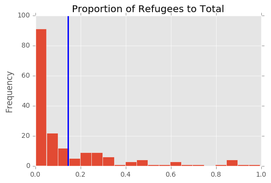

```python
greencard['refugee_to_total'].plot.hist(bins = 20,title = 'Proportion of Refugees to Total',grid = True)
plt.axvline(greencard['refugee_to_total'].mean(),color ='b',linewidth = 2)
print greencard['refugee_to_total'].mean()
plt.show()
```

In the above histogram we see that most countries have almost no refugees coming into the United States due to the very heavy skew to the right with the blue line being the average putting it at 14.4%. THere are some that border on 100% total as well but it seems to only be one.

```
0.472584514312
```

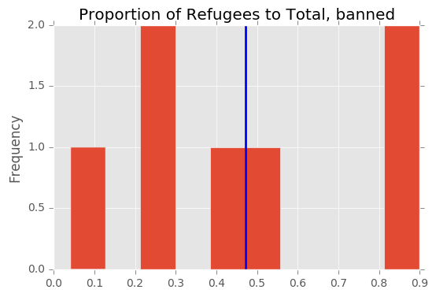

```python
truesgreen['refugee_to_total'].plot.hist(bins = 10,title = 'Proportion of Refugees to Total, banned',grid = True)
plt.axvline(truesgreen['refugee_to_total'].mean(),color ='b',linewidth = 2)
print truesgreen['refugee_to_total'].mean()
plt.show()
```

We then looked at all the countries that were on the banned list and plotted their refugee proportions. This showed us that 2 of the countries were very high on the list in the 80%+ level but there was also one country that is less than 10% which is Yemen with only 4% of them being refugees. We see the average at 47.2% on this one as well which is significantly higher than the full set.

```
0.131143808384
```

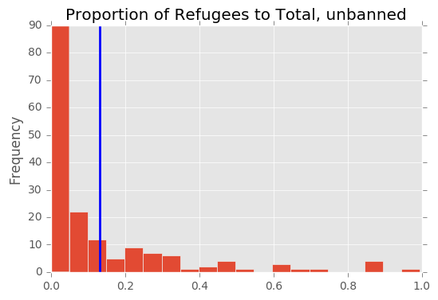

```python
falsesgreen['refugee_to_total'].plot.hist(bins = 20,title = 'Proportion of Refugees to Total, unbanned',grid = True)
plt.axvline(falsesgreen['refugee_to_total'].mean(),color ='b',linewidth = 2)
print falsesgreen['refugee_to_total'].mean()
plt.show()
```

When looking at countries that are not banned we find that it does not look oo different but there are still a good number of values that are very high including the highest one. The overall proportion fell a small amount to 13.1%

```python
greencard.sort('refugee_to_total',ascending=False).head(10)
```

|  | country | Total | Family-sponsored preferences | Employment-based preferences | Immediate relatives of U.S. citizens | Diversity | Refugees and asylees | Other | refugee_to_total | banned |
| --- | --- | --- | --- | --- | --- | --- | --- | --- | --- | --- |
| 22 | Bhutan | 6325.0 | NaN | 4.0 | 28.0 | NaN | 6290.0 | 0.0 | 0.994466 | False |
| 87 | Iraq | 21107.0 | 209.0 | 68.0 | 866.0 | 37.0 | 18973.0 | 954.0 | 0.898896 | True |
| 31 | Burma | 12808.0 | 486.0 | NaN | 688.0 | 134.0 | 11443.0 | NaN | 0.893426 | False |
| 48 | Cuba | 54396.0 | 2211.0 | 9.0 | 3882.0 | 428.0 | 47803.0 | 63.0 | 0.878796 | False |
| 38 | Central African Republic | 234.0 | NaN | 6.0 | 19.0 | NaN | 205.0 | 0.0 | 0.876068 | False |
| 54 | Djibouti | 370.0 | NaN | NaN | 34.0 | 12.0 | 319.0 | 0.0 | 0.862162 | False |
| 164 | Somalia | 6796.0 | 116.0 | NaN | 986.0 | 56.0 | 5630.0 | NaN | 0.828428 | True |
| 39 | Chad | 175.0 | NaN | NaN | 29.0 | 10.0 | 129.0 | 1.0 | 0.737143 | False |
| 32 | Burundi | 351.0 | 9.0 | 8.0 | 60.0 | 40.0 | 234.0 | 0.0 | 0.666667 | False |
| 44 | Congo, Republic | 496.0 | 20.0 | 3.0 | 87.0 | 68.0 | 313.0 | 5.0 | 0.631048 | False |

In this we get the ten countries with the highest refugee totals. From thsi we see that only 2 of the countries, Iraq and Somalia, are in this top 10 list. One that I found surprising, but thought it made sense, was Cuba being so high on the list! It makes sense that it is there but I was not initially expecting it.

```python
greencard.groupby(by= 'banned').mean()
#many have 0 which skews the data, look at medians
```

| banned | Total | Family-sponsored preferences | Employment-based preferences | Immediate relatives of U.S. citizens | Diversity | Refugees and asylees | Other | refugee_to_total |
| --- | --- | --- | --- | --- | --- | --- | --- | --- |
| False | 5174.435233 | 1240.881657 | 824.901163 | 2408.587302 | 266.872727 | 708.295858 | 166.444444 | 0.131144 |
| True | 7480.714286 | 582.285714 | 374.200000 | 1384.285714 | 544.285714 | 4557.428571 | 195.200000 | 0.472585 |

```python
greencard.groupby(by= 'banned').median()
#also hard to do since there are only 7 countries
```

| banned | Total | Family-sponsored preferences | Employment-based preferences | Immediate relatives of U.S. citizens | Diversity | Refugees and asylees | Other | refugee_to_total |
| --- | --- | --- | --- | --- | --- | --- | --- | --- |
| False | 875.0 | 103.0 | 87.5 | 511.0 | 41.0 | 47.0 | 7.0 | 0.041479 |
| True | 3840.0 | 209.0 | 68.0 | 986.0 | 136.0 | 1975.0 | 5.0 | 0.404632 |

```python
greencard.groupby(by= 'banned').std()
#very high std dev
```

| banned | Total | Family-sponsored preferences | Employment-based preferences | Immediate relatives of U.S. citizens | Diversity | Refugees and asylees | Other | refugee_to_total |
| --- | --- | --- | --- | --- | --- | --- | --- | --- |
| False | 15144.772610 | 4485.837863 | 2980.651141 | 8147.619015 | 570.710577 | 3901.032560 | 1077.365276 | 0.203852 |
| True | 7190.767801 | 788.579676 | 627.434220 | 1058.903476 | 874.819165 | 6654.417552 | 424.214215 | 0.308354 |

All of the above are our summary statistics for each of the data values depending on if they are true or false to see what there is. From this we see that the standard deviations are very high and both the medians and the mean have a much higher 'refugee_to_total' values too.

```python
ttest_ind(truesgreen['refugee_to_total'], falsesgreen['refugee_to_total'],nan_policy='omit')
```

```
Ttest_indResult(statistic=4.2491215437520609, pvalue=3.4914764184732473e-05)
```

```python
scipy.stats.mannwhitneyu(truesgreen['refugee_to_total'], falsesgreen['refugee_to_total'])
```

```
MannwhitneyuResult(statistic=335.0, pvalue=0.011808980415347741)
```

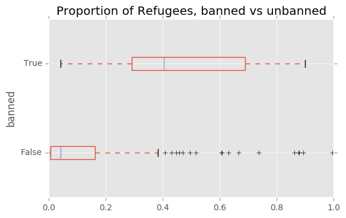

```python
greencard.boxplot('refugee_to_total',by='banned',vert=False)
plt.title("Proportion of Refugees, banned vs unbanned")
plt.xlabel('')
plt.ylabel('banned')
plt.suptitle('')
plt.show()
```

In the above boxplot we see the banned vs unbanned issue at the forefront and the difference between the two with even the Q3 of the unbanned being lower than the Q1 of the banned countries. Though there are many outliers for the unbanend countries as is seen, still most values are much lower.

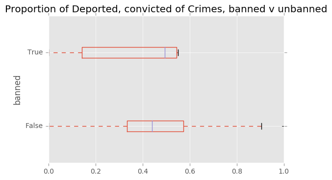

```python
remove2015.boxplot('proportion_crim',by='banned',vert = False)
plt.title("Proportion of Deported, convicted of Crimes, banned v unbanned")
plt.xlabel('')
plt.ylabel('banned')
plt.suptitle('')
plt.show()
```

Above we see the banned vs unbanned for the proportion of people removed due to crimes in boxplot format. We see that they are fairly similar with the banned countries having lower Q1 and Q3 than unbanned nations and the unbanned nations having a much higher upper range too. This shows that they may be equal to one another in testing.

```python
remove2015.groupby(by= 'banned').mean()
```

| banned | Total | Criminal 1 | Non-Criminal | proportion_crim |
| --- | --- | --- | --- | --- |
| False | 2266.319728 | 1184.059322 | 1622.873950 | 0.464255 |
| True | 30.000000 | 6.833333 | 23.166667 | 0.353504 |

```python
remove2015.groupby(by= 'banned').median()
```

| banned | Total | Criminal 1 | Non-Criminal | proportion_crim |
| --- | --- | --- | --- | --- |
| False | 21.0 | 15.0 | 17.0 | 0.440627 |
| True | 16.5 | 6.5 | 7.5 | 0.493369 |

```python
remove2015.groupby(by= 'banned').std()
```

| banned | Total | Criminal 1 | Non-Criminal | proportion_crim |
| --- | --- | --- | --- | --- |
| False | 20274.860972 | 9848.737831 | 12728.540248 | 0.204729 |
| True | 36.758672 | 4.708149 | 37.402763 | 0.261774 |

Above is a collection of all the summary statistics for the 'remove2015' dataframe which shows similar std deviations and near equal median though banned countries has a lower mean of proportion criminal.

```python
truesremove = remove2015[remove2015['banned']==True]
falsesremove = remove2015[remove2015['banned']==False]

ttest_ind(truesremove['proportion_crim'], falsesremove['proportion_crim'],nan_policy='omit')
```

```
Ttest_indResult(statistic=-1.2753301514009381, pvalue=0.20465587931689089)
```

```python
scipy.stats.mannwhitneyu(truesremove['proportion_crim'], falsesremove['proportion_crim'])
```

```
MannwhitneyuResult(statistic=307.0, pvalue=0.079899630451408743)
```

Overall this gives a conclusion that while the banned countries are bringing in more refugees, they are not bringing in criminals per say at a larger rate than other countries. This discredits the "bad hombres" argument that President Trump seems to enjoy making when talking about the reasoning behind the travel ban.

## Now to map the proportions that are refugees on a map

```python
fig, ax = plt.subplots(figsize=(15,30))
```

```python
m = Basemap(resolution='h', # c, l, i, h, f or None
            projection='merc',
            lat_0=25.5, lon_0=10.8,
            llcrnrlon=-180.7, llcrnrlat= -56.7, urcrnrlon=180, urcrnrlat=78)
```

```python
m.drawmapboundary(fill_color='#46bcec')
m.fillcontinents(color='#f2f2f2',lake_color='#46bcec')
m.drawcoastlines()
m.readshapefile('Shapefile/ne_110m_admin_0_countries','country')
```

```python
df_poly = pd.DataFrame({
        'shapes': [Polygon(np.array(shape), True) for shape in m.country],
        'country': [info['brk_name'] for info in m.country_info]
        })

df_poly = df_poly.merge(greencard, on='country', how='left')
```

```python
df_poly
```

|  | country | shapes | Total | Family-sponsored preferences | Employment-based preferences | Immediate relatives of U.S. citizens | Diversity | Refugees and asylees | Other | refugee_to_total | banned |
| --- | --- | --- | --- | --- | --- | --- | --- | --- | --- | --- | --- |
| 0 | Afghanistan | Poly((2.68992e+07, 1.19382e+07) ...) | 8328.0 | 272.0 | 16.0 | 1011.0 | 50.0 | 691.0 | 6288.0 | 0.082973 | False |
| 1 | Angola | Poly((2.19083e+07, 7.03573e+06) ...) | 154.0 | 8.0 | 12.0 | 89.0 | 6.0 | 39.0 | 0.0 | 0.253247 | False |
| 2 | Angola | Poly((2.14758e+07, 7.05732e+06) ...) | 154.0 | 8.0 | 12.0 | 89.0 | 6.0 | 39.0 | 0.0 | 0.253247 | False |
| 3 | Albania | Poly((2.23824e+07, 1.2824e+07) ...) | 4653.0 | 614.0 | 81.0 | 2017.0 | 1770.0 | 152.0 | 19.0 | 0.032667 | False |
| 4 | United Arab Emirates | Poly((2.58283e+07, 1.04707e+07) ...) | 1193.0 | 209.0 | 312.0 | 303.0 | 118.0 | 238.0 | 13.0 | 0.199497 | False |
| 5 | Argentina | Poly((1.28096e+07, 297934) ...) | 3730.0 | 194.0 | 1095.0 | 2194.0 | 48.0 | 133.0 | 66.0 | 0.035657 | False |
| 6 | Argentina | Poly((1.28692e+07, 5.17261e+06) ...) | 3730.0 | 194.0 | 1095.0 | 2194.0 | 48.0 | 133.0 | 66.0 | 0.035657 | False |
| 7 | Armenia | Poly((2.49391e+07, 1.27107e+07) ...) | 2962.0 | 247.0 | 120.0 | 1035.0 | 1324.0 | 225.0 | 11.0 | 0.075962 | False |
| 8 | Antarctica | Poly((1.34688e+07, -7.85667e+06) ...) | NaN | NaN | NaN | NaN | NaN | NaN | NaN | NaN | NaN |
| 9 | Antarctica | Poly((2.38978e+06, -7.51659e+06) ...) | NaN | NaN | NaN | NaN | NaN | NaN | NaN | NaN | NaN |
| 10 | Antarctica | Poly((1.50719e+07, -6.68739e+06) ...) | NaN | NaN | NaN | NaN | NaN | NaN | NaN | NaN | NaN |
| 11 | Antarctica | Poly((6.61482e+06, -4.6128e+06) ...) | NaN | NaN | NaN | NaN | NaN | NaN | NaN | NaN | NaN |
| 12 | Antarctica | Poly((6.13133e+06, -4.60511e+06) ...) | NaN | NaN | NaN | NaN | NaN | NaN | NaN | NaN | NaN |
| 13 | Antarctica | Poly((9.08667e+06, -4.02565e+06) ...) | NaN | NaN | NaN | NaN | NaN | NaN | NaN | NaN | NaN |
| 14 | Antarctica | Poly((1.24815e+07, -3.68401e+06) ...) | NaN | NaN | NaN | NaN | NaN | NaN | NaN | NaN | NaN |
| 15 | Antarctica | Poly((1.35753e+07, -1.68765e+06) ...) | NaN | NaN | NaN | NaN | NaN | NaN | NaN | NaN | NaN |
| 16 | Fr. S. and Antarctic Lands | Poly((2.77581e+07, 1.48591e+06) ...) | NaN | NaN | NaN | NaN | NaN | NaN | NaN | NaN | NaN |
| 17 | Australia | Poly((3.62604e+07, 2.71421e+06) ...) | 3034.0 | 68.0 | 930.0 | 1636.0 | 390.0 | NaN | NaN | NaN | False |
| 18 | Australia | Poly((3.60563e+07, 6.14504e+06) ...) | 3034.0 | 68.0 | 930.0 | 1636.0 | 390.0 | NaN | NaN | NaN | False |
| 19 | Austria | Poly((2.1981e+07, 1.3811e+07) ...) | 474.0 | 17.0 | 166.0 | 247.0 | 39.0 | 5.0 | 0.0 | 0.010549 | False |
| 20 | Azerbaijan | Poly((2.50969e+07, 1.25133e+07) ...) | 676.0 | 70.0 | 34.0 | 291.0 | 229.0 | 49.0 | 3.0 | 0.072485 | False |
| 21 | Azerbaijan | Poly((2.53606e+07, 1.27296e+07) ...) | 676.0 | 70.0 | 34.0 | 291.0 | 229.0 | 49.0 | 3.0 | 0.072485 | False |
| 22 | Burundi | Poly((2.33554e+07, 7.18954e+06) ...) | 351.0 | 9.0 | 8.0 | 60.0 | 40.0 | 234.0 | 0.0 | 0.666667 | False |
| 23 | Belgium | Poly((2.04615e+07, 1.43656e+07) ...) | 662.0 | 14.0 | 303.0 | 298.0 | 40.0 | NaN | NaN | NaN | False |
| 24 | Benin | Poly((2.03922e+07, 8.38776e+06) ...) | 466.0 | 19.0 | 11.0 | 233.0 | 180.0 | 19.0 | 4.0 | 0.040773 | False |
| 25 | Burkina Faso | Poly((1.97785e+07, 8.76772e+06) ...) | 575.0 | 33.0 | 15.0 | 274.0 | 98.0 | 152.0 | 3.0 | 0.264348 | False |
| 26 | Bangladesh | Poly((3.03976e+07, 1.02041e+07) ...) | 13570.0 | 7044.0 | 653.0 | 5667.0 | 0.0 | 167.0 | 39.0 | 0.012307 | False |
| 27 | Bulgaria | Poly((2.26123e+07, 1.31861e+07) ...) | 2688.0 | 130.0 | 301.0 | 1379.0 | 819.0 | 45.0 | 14.0 | 0.016741 | False |
| 28 | Bahamas | Poly((1.14715e+07, 1.04115e+07) ...) | 725.0 | 53.0 | 84.0 | 562.0 | 6.0 | 14.0 | 6.0 | 0.019310 | False |
| 29 | Bahamas | Poly((1.14397e+07, 1.07581e+07) ...) | 725.0 | 53.0 | 84.0 | 562.0 | 6.0 | 14.0 | 6.0 | 0.019310 | False |
| ... | ... | ... | ... | ... | ... | ... | ... | ... | ... | ... | ... |
| 257 | Timor-Leste | Poly((3.39888e+07, 6.6976e+06) ...) | NaN | NaN | NaN | NaN | NaN | NaN | NaN | NaN | NaN |
| 258 | Trinidad and Tobago | Poly((1.32344e+07, 8.89398e+06) ...) | 3212.0 | 651.0 | 272.0 | 2188.0 | 53.0 | 4.0 | 44.0 | 0.001245 | False |
| 259 | Tunisia | Poly((2.11473e+07, 1.12296e+07) ...) | 518.0 | 20.0 | 56.0 | 351.0 | 41.0 | 45.0 | 5.0 | 0.086873 | False |
| 260 | Turkey | Poly((2.41975e+07, 1.27467e+07) ...) | 4201.0 | 222.0 | 1041.0 | 1670.0 | 1108.0 | 142.0 | 18.0 | 0.033801 | False |
| 261 | Turkey | Poly((2.31166e+07, 1.26517e+07) ...) | 4201.0 | 222.0 | 1041.0 | 1670.0 | 1108.0 | 142.0 | 18.0 | 0.033801 | False |
| 262 | Taiwan | Poly((3.3634e+07, 1.04888e+07) ...) | 4888.0 | 662.0 | 2119.0 | 1950.0 | 138.0 | NaN | NaN | NaN | False |
| 263 | Tanzania | Poly((2.38628e+07, 7.58479e+06) ...) | 799.0 | 59.0 | NaN | 406.0 | 66.0 | 211.0 | NaN | 0.264080 | False |
| 264 | Uganda | Poly((2.36363e+07, 7.57618e+06) ...) | 1664.0 | 122.0 | 135.0 | 686.0 | 185.0 | 531.0 | 5.0 | 0.319111 | False |
| 265 | Ukraine | Poly((2.36274e+07, 1.45013e+07) ...) | 7987.0 | 797.0 | 881.0 | 4519.0 | 1285.0 | 471.0 | 34.0 | 0.058971 | False |
| 266 | Uruguay | Poly((1.36853e+07, 4.163e+06) ...) | 1078.0 | 37.0 | 115.0 | 834.0 | 5.0 | 47.0 | 40.0 | 0.043599 | False |
| 267 | United States | Poly((2.79743e+06, 9.85277e+06) ...) | 370.0 | 12.0 | 43.0 | 270.0 | 0.0 | 19.0 | 26.0 | 0.051351 | False |
| 268 | United States | Poly((2.7377e+06, 1.00373e+07) ...) | 370.0 | 12.0 | 43.0 | 270.0 | 0.0 | 19.0 | 26.0 | 0.051351 | False |
| 269 | United States | Poly((2.6622e+06, 1.01007e+07) ...) | 370.0 | 12.0 | 43.0 | 270.0 | 0.0 | 19.0 | 26.0 | 0.051351 | False |
| 270 | United States | Poly((2.56273e+06, 1.0118e+07) ...) | 370.0 | 12.0 | 43.0 | 270.0 | 0.0 | 19.0 | 26.0 | 0.051351 | False |
| 271 | United States | Poly((2.37455e+06, 1.0197e+07) ...) | 370.0 | 12.0 | 43.0 | 270.0 | 0.0 | 19.0 | 26.0 | 0.051351 | False |
| 272 | United States | Poly((9.54968e+06, 1.40245e+07) ...) | 370.0 | 12.0 | 43.0 | 270.0 | 0.0 | 19.0 | 26.0 | 0.051351 | False |
| 273 | United States | Poly((3.0794e+06, 1.54655e+07) ...) | 370.0 | 12.0 | 43.0 | 270.0 | 0.0 | 19.0 | 26.0 | 0.051351 | False |
| 274 | United States | Poly((1.68136e+06, 1.60608e+07) ...) | 370.0 | 12.0 | 43.0 | 270.0 | 0.0 | 19.0 | 26.0 | 0.051351 | False |
| 275 | United States | Poly((997234, 1.69748e+07) ...) | 370.0 | 12.0 | 43.0 | 270.0 | 0.0 | 19.0 | 26.0 | 0.051351 | False |
| 276 | United States | Poly((2.85017e+06, 1.91306e+07) ...) | 370.0 | 12.0 | 43.0 | 270.0 | 0.0 | 19.0 | 26.0 | 0.051351 | False |
| 277 | Uzbekistan | Poly((2.74894e+07, 1.21752e+07) ...) | 3977.0 | 396.0 | 131.0 | 805.0 | 2318.0 | 306.0 | 21.0 | 0.076942 | False |
| 278 | Venezuela | Poly((1.21612e+07, 9.00921e+06) ...) | 9144.0 | 731.0 | 2207.0 | 4610.0 | 738.0 | 806.0 | 52.0 | 0.088145 | False |
| 279 | Vietnam | Poly((3.21075e+07, 1.01455e+07) ...) | 30832.0 | 16065.0 | 872.0 | 13690.0 | NaN | 148.0 | NaN | 0.004800 | False |
| 280 | Vanuatu | Poly((3.87564e+07, 5.83372e+06) ...) | NaN | NaN | NaN | NaN | NaN | NaN | NaN | NaN | NaN |
| 281 | Vanuatu | Poly((3.86744e+07, 6.01072e+06) ...) | NaN | NaN | NaN | NaN | NaN | NaN | NaN | NaN | NaN |
| 282 | Yemen | Poly((2.59983e+07, 9.56857e+06) ...) | 3194.0 | 577.0 | 25.0 | 2319.0 | 136.0 | 134.0 | 3.0 | 0.041954 | True |
| 283 | South Africa | Poly((2.35979e+07, 4.2858e+06) ...) | 2907.0 | 77.0 | 935.0 | 1286.0 | 262.0 | 332.0 | 15.0 | 0.114207 | False |
| 284 | South Africa | Poly((2.33151e+07, 4.32421e+06) ...) | 2907.0 | 77.0 | 935.0 | 1286.0 | 262.0 | 332.0 | 15.0 | 0.114207 | False |
| 285 | Zambia | Poly((2.37356e+07, 6.65956e+06) ...) | 460.0 | 31.0 | 75.0 | 272.0 | 35.0 | 44.0 | 3.0 | 0.095652 | False |
| 286 | Zimbabwe | Poly((2.35612e+07, 5.15152e+06) ...) | 779.0 | 60.0 | 167.0 | 311.0 | 42.0 | 189.0 | 10.0 | 0.242619 | False |

287 rows × 11 columns

```python
m.fillcontinents(color='#f2f2f2',lake_color='#46bcec')
m.drawcoastlines()

m.readshapefile('Shapefile/ne_110m_admin_0_countries','country')
cmap = plt.get_cmap('PuBuGn')
pc = PatchCollection(df_poly.shapes, zorder=2)
norm = Normalize()

pc.set_facecolor(cmap(norm(df_poly['refugee_to_total'].fillna(0).values)))
ax.add_collection(pc)

mapper = matplotlib.cm.ScalarMappable(norm=norm, cmap=cmap)

mapper.set_array(df_poly['refugee_to_total'])
plt.colorbar(mapper, shrink=0.3)

m.readshapefile('Shapefile/ne_110m_admin_0_countries','country')
plt.title("Proportion of Green Card Recipiants who are Refugees")
```

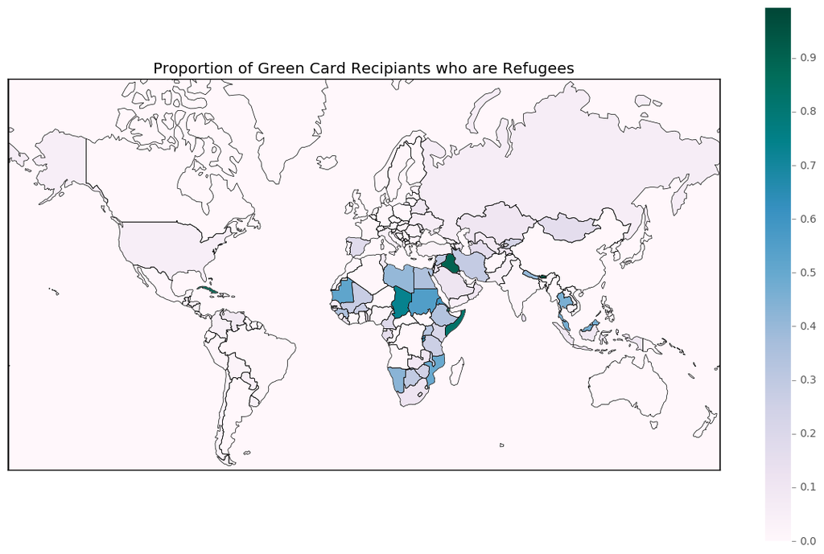

```python
plt.show()
```

From the map we see that the countries with the highest refugee proportions primarily are in Africa and the middle east and some South East Asian nations. We used Basemap to draw this and figure out what regions had the most

```python
fig, ax = plt.subplots(figsize=(15,30))
```

```python
m = Basemap(resolution='c', # c, l, i, h, f or None
            projection='merc',
            lat_0=25.5, lon_0=10.8,
            llcrnrlon=-180.7, llcrnrlat= -56.7, urcrnrlon=180, urcrnrlat=78)
```

```python
m.drawmapboundary(fill_color='#46bcec')
m.fillcontinents(color='#f2f2f2',lake_color='#46bcec')
m.drawcoastlines()
m.readshapefile('Shapefile/ne_110m_admin_0_countries','country')
```

[output not shown]

```python
df_crime = pd.DataFrame({
        'shapes': [Polygon(np.array(shape), True) for shape in m.country],
        'country': [info['brk_name'] for info in m.country_info]
        })

df_crime = df_crime.merge(remove2015, on='country', how='left')
df_crime
```

|  | country | shapes | Total | Criminal 1 | Non-Criminal | proportion_crim | banned |
| --- | --- | --- | --- | --- | --- | --- | --- |
| 0 | Afghanistan | Poly((2.68992e+07, 1.19382e+07) ...) | 9.0 | NaN | NaN | NaN | False |
| 1 | Angola | Poly((2.19083e+07, 7.03573e+06) ...) | 10.0 | 3.0 | 7.0 | 0.300000 | False |
| 2 | Angola | Poly((2.14758e+07, 7.05732e+06) ...) | 10.0 | 3.0 | 7.0 | 0.300000 | False |
| 3 | Albania | Poly((2.23824e+07, 1.2824e+07) ...) | 40.0 | 21.0 | 19.0 | 0.525000 | False |
| 4 | United Arab Emirates | Poly((2.58283e+07, 1.04707e+07) ...) | NaN | 0.0 | NaN | NaN | False |
| 5 | Argentina | Poly((1.28096e+07, 297934) ...) | 132.0 | 58.0 | 74.0 | 0.439394 | False |
| 6 | Argentina | Poly((1.28692e+07, 5.17261e+06) ...) | 132.0 | 58.0 | 74.0 | 0.439394 | False |
| 7 | Armenia | Poly((2.49391e+07, 1.27107e+07) ...) | 16.0 | NaN | NaN | NaN | False |
| 8 | Antarctica | Poly((1.34688e+07, -7.85667e+06) ...) | NaN | NaN | NaN | NaN | NaN |
| 9 | Antarctica | Poly((2.38978e+06, -7.51659e+06) ...) | NaN | NaN | NaN | NaN | NaN |
| 10 | Antarctica | Poly((1.50719e+07, -6.68739e+06) ...) | NaN | NaN | NaN | NaN | NaN |
| 11 | Antarctica | Poly((6.61482e+06, -4.6128e+06) ...) | NaN | NaN | NaN | NaN | NaN |
| 12 | Antarctica | Poly((6.13133e+06, -4.60511e+06) ...) | NaN | NaN | NaN | NaN | NaN |
| 13 | Antarctica | Poly((9.08667e+06, -4.02565e+06) ...) | NaN | NaN | NaN | NaN | NaN |
| 14 | Antarctica | Poly((1.24815e+07, -3.68401e+06) ...) | NaN | NaN | NaN | NaN | NaN |
| 15 | Antarctica | Poly((1.35753e+07, -1.68765e+06) ...) | NaN | NaN | NaN | NaN | NaN |
| 16 | Fr. S. and Antarctic Lands | Poly((2.77581e+07, 1.48591e+06) ...) | NaN | NaN | NaN | NaN | NaN |
| 17 | Australia | Poly((3.62604e+07, 2.71421e+06) ...) | 32.0 | 16.0 | 16.0 | 0.500000 | False |
| 18 | Australia | Poly((3.60563e+07, 6.14504e+06) ...) | 32.0 | 16.0 | 16.0 | 0.500000 | False |
| 19 | Austria | Poly((2.1981e+07, 1.3811e+07) ...) | 7.0 | 3.0 | 4.0 | 0.428571 | False |
| 20 | Azerbaijan | Poly((2.50969e+07, 1.25133e+07) ...) | NaN | NaN | NaN | NaN | NaN |
| 21 | Azerbaijan | Poly((2.53606e+07, 1.27296e+07) ...) | NaN | NaN | NaN | NaN | NaN |
| 22 | Burundi | Poly((2.33554e+07, 7.18954e+06) ...) | NaN | NaN | NaN | NaN | NaN |
| 23 | Belgium | Poly((2.04615e+07, 1.43656e+07) ...) | 7.0 | 4.0 | 3.0 | 0.571429 | False |
| 24 | Benin | Poly((2.03922e+07, 8.38776e+06) ...) | 8.0 | 3.0 | 5.0 | 0.375000 | False |
| 25 | Burkina Faso | Poly((1.97785e+07, 8.76772e+06) ...) | 24.0 | NaN | NaN | NaN | False |
| 26 | Bangladesh | Poly((3.03976e+07, 1.02041e+07) ...) | 64.0 | 13.0 | 51.0 | 0.203125 | False |
| 27 | Bulgaria | Poly((2.26123e+07, 1.31861e+07) ...) | 34.0 | 17.0 | 17.0 | 0.500000 | False |
| 28 | Bahamas | Poly((1.14715e+07, 1.04115e+07) ...) | 73.0 | 66.0 | 7.0 | 0.904110 | False |
| 29 | Bahamas | Poly((1.14397e+07, 1.07581e+07) ...) | 73.0 | 66.0 | 7.0 | 0.904110 | False |
| ... | ... | ... | ... | ... | ... | ... | ... |
| 257 | Timor-Leste | Poly((3.39888e+07, 6.6976e+06) ...) | NaN | NaN | NaN | NaN | NaN |
| 258 | Trinidad and Tobago | Poly((1.32344e+07, 8.89398e+06) ...) | 126.0 | 102.0 | 24.0 | 0.809524 | False |
| 259 | Tunisia | Poly((2.11473e+07, 1.12296e+07) ...) | 16.0 | 7.0 | 9.0 | 0.437500 | False |
| 260 | Turkey | Poly((2.41975e+07, 1.27467e+07) ...) | 52.0 | 14.0 | 38.0 | 0.269231 | False |
| 261 | Turkey | Poly((2.31166e+07, 1.26517e+07) ...) | 52.0 | 14.0 | 38.0 | 0.269231 | False |
| 262 | Taiwan | Poly((3.3634e+07, 1.04888e+07) ...) | 31.0 | 9.0 | 22.0 | 0.290323 | False |
| 263 | Tanzania | Poly((2.38628e+07, 7.58479e+06) ...) | 19.0 | 10.0 | 9.0 | 0.526316 | False |
| 264 | Uganda | Poly((2.36363e+07, 7.57618e+06) ...) | 9.0 | 4.0 | 5.0 | 0.444444 | False |
| 265 | Ukraine | Poly((2.36274e+07, 1.45013e+07) ...) | 89.0 | 39.0 | 50.0 | 0.438202 | False |
| 266 | Uruguay | Poly((1.36853e+07, 4.163e+06) ...) | 34.0 | 16.0 | 18.0 | 0.470588 | False |
| 267 | United States | Poly((2.79743e+06, 9.85277e+06) ...) | NaN | NaN | NaN | NaN | NaN |
| 268 | United States | Poly((2.7377e+06, 1.00373e+07) ...) | NaN | NaN | NaN | NaN | NaN |
| 269 | United States | Poly((2.6622e+06, 1.01007e+07) ...) | NaN | NaN | NaN | NaN | NaN |
| 270 | United States | Poly((2.56273e+06, 1.0118e+07) ...) | NaN | NaN | NaN | NaN | NaN |
| 271 | United States | Poly((2.37455e+06, 1.0197e+07) ...) | NaN | NaN | NaN | NaN | NaN |
| 272 | United States | Poly((9.54968e+06, 1.40245e+07) ...) | NaN | NaN | NaN | NaN | NaN |
| 273 | United States | Poly((3.0794e+06, 1.54655e+07) ...) | NaN | NaN | NaN | NaN | NaN |
| 274 | United States | Poly((1.68136e+06, 1.60608e+07) ...) | NaN | NaN | NaN | NaN | NaN |
| 275 | United States | Poly((997234, 1.69748e+07) ...) | NaN | NaN | NaN | NaN | NaN |
| 276 | United States | Poly((2.85017e+06, 1.91306e+07) ...) | NaN | NaN | NaN | NaN | NaN |
| 277 | Uzbekistan | Poly((2.74894e+07, 1.21752e+07) ...) | 14.0 | 8.0 | 6.0 | 0.571429 | False |
| 278 | Venezuela | Poly((1.21612e+07, 9.00921e+06) ...) | 204.0 | 61.0 | 143.0 | 0.299020 | False |
| 279 | Vietnam | Poly((3.21075e+07, 1.01455e+07) ...) | 45.0 | 18.0 | 27.0 | 0.400000 | False |
| 280 | Vanuatu | Poly((3.87564e+07, 5.83372e+06) ...) | NaN | NaN | NaN | NaN | NaN |
| 281 | Vanuatu | Poly((3.86744e+07, 6.01072e+06) ...) | NaN | NaN | NaN | NaN | NaN |
| 282 | Yemen | Poly((2.59983e+07, 9.56857e+06) ...) | 13.0 | 7.0 | 6.0 | 0.538462 | True |
| 283 | South Africa | Poly((2.35979e+07, 4.2858e+06) ...) | 49.0 | 16.0 | 33.0 | 0.326531 | False |
| 284 | South Africa | Poly((2.33151e+07, 4.32421e+06) ...) | 49.0 | 16.0 | 33.0 | 0.326531 | False |
| 285 | Zambia | Poly((2.37356e+07, 6.65956e+06) ...) | 13.0 | NaN | NaN | NaN | False |
| 286 | Zimbabwe | Poly((2.35612e+07, 5.15152e+06) ...) | 11.0 | 6.0 | 5.0 | 0.545455 | False |

287 rows × 7 columns

```python
m.fillcontinents(color='#f2f2f2',lake_color='#46bcec')
m.drawcoastlines()

m.readshapefile('Shapefile/ne_110m_admin_0_countries','country')
cmap = plt.get_cmap('PuBuGn')
pc = PatchCollection(df_crime.shapes, zorder=2)
norm = Normalize()

pc.set_facecolor(cmap(norm(df_crime['proportion_crim'].fillna(0).values)))
ax.add_collection(pc)

mapper = matplotlib.cm.ScalarMappable(norm=norm, cmap=cmap)

mapper.set_array(df_crime['proportion_crim'])
plt.colorbar(mapper, shrink=0.3)

m.readshapefile('Shapefile/ne_110m_admin_0_countries','country')
plt.title("Proportion of People who are Criminals and removed")
```

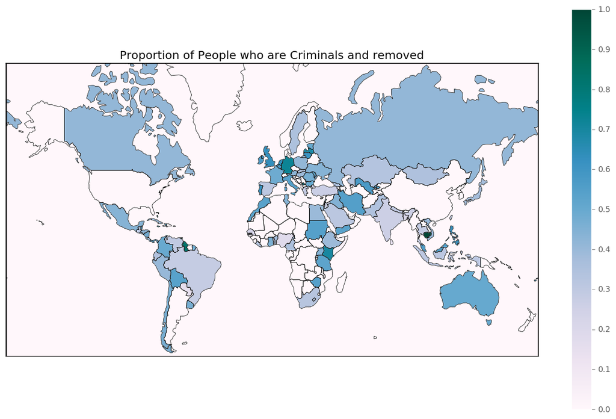

```python
plt.show()
```

In this map we are looking at the proportion of individuals who were removed who were convicted criminals. This shows that the countries that were major places where criminals were removed were not really the countries that were banned or had large proportions of refugees coming from!

## Austin Package for Twitter Scraping

Below is the package 'Austin' (created by Austin obviously) that was used for the 'save_game' function that we saw above and the scraping of Twitter that was built around the tweepy package. We will go over each function here:

- The "save_game" function which takes a Pandas dataframe and saves it as an sqlite database and names it as the date
- The Auth is the creation of a class which takes the API keys needed to scrape twitterand puts them all together.
- StreamSaver takes the dataframe from Twitter and then appends it to the sqlite file. It also prints the tweet but this it turned off for long term use since it caused python to overload and the code to just stop.
- createconnectiontostreamer takes in the APIs and puts it into the stream which is used to start up the function and log in.
- streamrestarter is how we start the scraping and it uses the previous 2 and save_game to make the sqlite file. We found when running that some errors occurred over time for strange reasons which we assumed were because we were getting kicked out due to taking too much data. We made it then that if we got errors the program would run again unless a keyboard interupt made it stop. We also put in a 5 second cooldown between errors to not overload things as well.

```python
import pandas as pd
import numpy as np
import sqlite3
from sqlalchemy import create_engine
import datetime
import tweepy
import time

def save_game(df,overwrite = "none",append = False):
    """Saves Pandas Dataframe to sqlite database. Takes in Pandas Dataframe and name of database(optional).
    Defualt name is the date."""
    if overwrite != "none":
        engine = create_engine('sqlite:///'+overwrite+'.sqlite')
        if  append == True:
            df.to_sql('table',engine,if_exists='append')
        else:
            df.to_sql('table',engine,if_exists='replace')
            print "You have succesfully saved!"
        return
    else :
        name = str(datetime.datetime.now().date()).replace(" ","").replace("-","").replace(":","").replace(".","")
        enginename = 'sqlite:///%s.sqlite' % name
        engine = create_engine(enginename)
        if append == True:
            df.to_sql('table',engine,if_exists='append')
        else:
            df.to_sql('table',engine,if_exists='replace')
            print "You have succesfully saved!"
        return

class Auth(object):
    def __init__(self):
        self.API_KEY = 	"9AVB69rIkU9mwFxkOxM8hfy1t"
        self.API_SECRET = "rhJU9HuvHAaMAoYDgbkwKuJlTnooEcGDbvQVzJfjlSMCmGzOKR"
        self.TWITTER_KEY = "24664791-skDfYfQUIacKDRnQotU76OQ7bqz3pl1osCXt4L2oq"
        self.TWITTER_SECRET = "rE5t774BYTOZlherSqxmwkRZPqk3M3rkuLcRufdxNbFBL"

class StreamSaver(tweepy.StreamListener):
    def on_status(self, status):
        temp = {"User" : status.user.screen_name,"Text" : status.text,"Coord" : status.coordinates,"Time" : status.created_at}
        tempdf = pd.DataFrame([temp])
        print tempdf
        save_game(tempdf,append = True,overwrite = "Twitter")

    def on_error(self, status_code):
        if status_code == 420:
            return False

def createconnectiontostreamer(a):
    """a is an Auth() object"""
    auth = tweepy.OAuthHandler(a.API_KEY, a.API_SECRET)
    auth.set_access_token(a.TWITTER_KEY, a.TWITTER_SECRET)
    api = tweepy.API(auth)
    stream_saver = StreamSaver()
    stream = tweepy.Stream(auth = api.auth, listener = stream_saver)
    return stream

def streamrestarter(a,listofsearch = ["muslim ban","travel ban"]):
    """a is auth object (get from createconnectiontostreamer()),
    listofsearch is list of search terms. """
    try:
        createconnectiontostreamer(a).filter(track=listofsearch)
        return
    except KeyboardInterrupt:
        createconnectiontostreamer(a).disconnect()
        return
    except:
        print "ERROR! RESTARTING IN 5 SECONDS!"
        time.sleep(5)
        streamrestarter(a,listofsearch)
        return
```

## Twitter Sentiment Analysis

We will be taking a look at sentiments in terms of supporting or opposing Donald Trump's highly controversial travel ban. The process of analyzing public sentiments involes a few steps. First off, considering that tweets are generally highly disorganized in terms of grammar and structure, some preprocessing is necessary. For the most parts, links given in tweets are useless for analysis since the classifying algorithm will only deal with the main body of text. At tags (@) will also be removed as they may not provide consistent information (a proponent or an opponent could tweet at somebody). The clean_text() function will be the main driver of the preprocessing. Tokenization/Lemmatization is done witht he nltk's WordNetLemmatizer. Also, the built-in nltk english stop words list is modified in order to filter out commonly occurring uniformative words(features). This includes the search terms which were used to stream tweets. The clean_text function was used accordingly on the training sample as well as the random sample for 10,000 tweets. Then, they are saved to 2 excel files for ease of access and saving time.

Considering the immense size of our streamed data, we resorted to randomly sampling 10,000 tweets from the database and classifying these. We found with this sample, 1437 out of the 10,000 tweets were in support of the travel ban. This is only a rough figure since there are many factors not considered which are beyond the scope of this analysis. For example, accounting for relevance might be an issue since the search terms may return unrelated tweets. However, overall we do see a majority of the tweets concerning this topic lean towards negativity.

```python
import nltk
import pandas as pd
from nltk.stem import WordNetLemmatizer
import numpy as np
from nltk.corpus import stopwords
import string
import random
import re
from wordcloud import WordCloud
```

```python
#modifying the built-in nltk english stop words list
eng_stop_mod = list(stopwords.words('english'))
for e in string.printable:
    if not e.isalpha(): #everything not alpha character
        eng_stop_mod.append(e)
eng_stop_mod = eng_stop_mod + ['trump', 'ban', 'muslim', 'rt','travel',"'s",'amp']

tokenize = nltk.word_tokenize #nltk tokenizer
lemma = WordNetLemmatizer().lemmatize #nltk WordNetLemmatizer
def lemmatize(text): #function to make it work for a whole text
    return [lemma(tok.lower()) for tok in tokenize(text)]

def clean_text(text_list):
    '''
    Removes links, @tags, takes care of troubling characters, stop words
    from a list of texts (tweets)
    '''
    cleaned = []
    for text in text_list:
        text = re.sub(r"htt\S+", "", text)
        text = re.sub('@\S+', '', text)
        text = text.translate({ 0x2018:0x27, 0x2019:0x27, 0x201C:0x22, 0x201D:0x22, 0x2026:0x20 })
        text = ' '.join(e for e in lemmatize(text) if e not in eng_stop_mod)
        cleaned.append(text)
    return cleaned
```

```python
train = pd.read_excel('train.xls') #already cleaned (2 cols. text and its sentiment category)

train_data = [] #format for Naive Bayes (list of tuple, each tuple has list of tokenized tweet and its sentiment)
for i in xrange(len(train)):
    train_data.append((list(tokenize(train['Text'][i])), train['class'][i])) #class is the sentiment (0,1)
train_data[:2]
```

```
[([u'uk', u'humanrights-', u'back', u'fight'], 0),
 ([u'hawaii', u'work', u'resist', u'noban'], 0)]
```

```python
all_words = [] #compile list of all words from training text
for text in train.Text:
    for w in tokenize(text):
        all_words.append(w)
#some filtering for non alpha characters/insignificant chars/words
all_words = [''.join(ch for ch in c if ch.isalpha() or ch == ' ') for c in all_words]
all_words = [e for e in all_words if e != '' and len(e) > 2]
all_words = nltk.FreqDist(all_words) #frequency dist. of all words

word_feats = [] #grabbing top 1000 most frequent words
for i in all_words.most_common(1000):
    word_feats.append(i[0])

#finding the features in form of dictionary(for each of 1000 top words: whether it exists in a text)
def find_feats(item):
    words = set(item) #exclue duplicates
    features = {}
    for w in word_feats:
        features[w] = (w in words)
    return features
```

```python
#sets of all features for our training data(list of tuples)
feat_sets = [(find_feats(tweet), sent) for (tweet,sent) in  train_data]

train_set = feat_sets[:700] #first 700 as training
test_set = feat_sets[700:] #the rest for testing
#use Naive Bayes classifier to train
classifier = nltk.NaiveBayesClassifier.train(train_set)
#accuracy rate with testing set
print nltk.classify.accuracy(classifier, test_set) * 100
```

```
84.5070422535
```

```python
def classify_tweet(tweet):
    '''
    classify each tweet(give the sentiment)
    '''
    #find the features for each tweet first
    feat = find_feats(tokenize(tweet))
    #classify using those features
    return classifier.classify(feat)
```

```python
# conn = sql.connect('Twitter.sqlite')
# # conn.close()
# tw_corp = list(pd.read_sql('SELECT Text FROM table1', conn)['Text'])
# tweet_sample = random.sample(tw_corp, 10000)
#Used for randomly sampling 10000 tweets from our database

#cleaned sample 10000 using clean_text function
tweet_sample = list(pd.read_excel('sample.xls').dropna()[0])
tweet_cleaned = clean_text(tweet_sample)
#convert to list, drop possible na's from resulting from cleaning/converting process

#Lets classify these cleaned tweets
#keeping track of classification(list of sentiments)

sentiments = []
for tweet in tweet_cleaned:
    sentiments.append(classify_tweet(tweet))

#print first 100
# for tweet in tweet_cleaned[:100]:
#     print classify_tweet(tweet), tweet
```

[output not shown]

[output cut: 85 more lines]

```python
sum(sentiments) #only 1437/10000 tweets are classified to be in support of the travel ban
```

```
1437
```

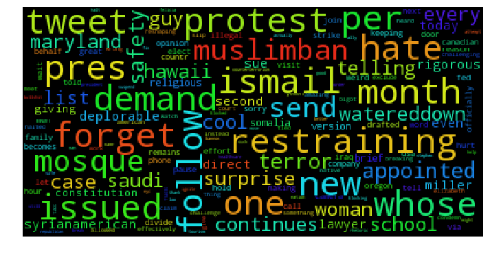

```python
#wordcloud representation of the top 500 words
plt.rcParams['figure.figsize'] = (12, 12)
def word_cloud(text):
    '''
    generate and show word cloud for the given text
    '''
    wc = WordCloud(max_font_size=30).generate(text)
    plt.figure()
    plt.imshow(wc)
    plt.axis("off")
    plt.show()
word_cloud(' '.join(word_feats[:500]))
```

Overall, typing together the analysis of our DHS data with the twitter sentiments, we get a broad picture of the many unsubstatiated claims of improving national security. We also take from twitter the current chaotic state of social unrest as a result of such level of controversy. Infering from data of previous years, the argument that the travel ban keeps out criminal stands on weak ground considering the proportions of deportation due to criminality for the target countries. The snapshot we get from twitter sentiments shows that people are not happy with the president's decision to instate a travel ban.

# Conclusion

In conclusion, we see from the DHS data that many thousands of individuals will be prevented from getting into the country over those 3 months and that while these countries bring in more refugees than non banned nations, they do not bring an more criminal immigrants into the country compared to other countries. When we ran to check the information on twitter against the travel ban, we saw that people were not supporting it on the large scale. We would like to say this is because there are not many criminals coming from the countries that are banned and partially due to political throwback against the current administration.